# Appendix B: Re-analysis of original data (Shebani and Pulvermüller, 2013)

[Guillermo Montero-Melis](https://www.mpi.nl/people/montero-melis-guillermo)

16/02/2020

# 1 Introduction

This report presents a re-analysis of the original data from the study Shebani and Pulvermüller (2013, *Cortex*, hereafter SP13). In the script we:

- Plot and summarize the data to check we obtain the same summaries as in SP13;
- Replicate the same ANOVAs reported in the original; we emphasize that an **ANOVA analysis is inappropriate for this type of error count data** and that it may lead to over-estimation of the effect size (see our manuscript and Jaeger, 2008).
- Try to figure out how SP13 arrived at the effect size measure they report;
- Re-analyze the data with more appropriate statistical methods.

*NB*:

- The original data have been made publicly available by the original authors at https://github.com/zshebani/LMB/tree/1.0 (DOI: 10.5281/zenodo.3402035).
- Some of the analyses and simulations run below take up a considerable amount of computation time. In these cases we have saved the output of the code to disk (to the “data/” subfolder) so that it can later be read without the need to re-run the analyses. If you wish to re-run the analyses, please uncomment the relevant code.
- For R version, loaded packages and their versions, etc., see session info at the end of this document.

# 2 Setup workspace

Load libraries

```r
library("knitr")
library("lme4")
library("brms")
library("tidyverse")  # ggplot2, dplyr, readr, purrr, etc
library("boot")       # for inv.logit()
library("DescTools")  # EtaSq()
library("lsr")        # cohensD()
library("sjPlot")     # tab_model()
# library("sjstats")    # eta_sq()
```

Load original data set:

```r
# Load data
d_allconds <- read_csv("data/SP13_orig-data_total-errors_long-format.csv")
d_allconds$subject <- factor(d_allconds$subject)
```

# 3 Describe and plot the data set

```r
kable(head(d_allconds))
```

| subject | movement | word_type | errors |
| --- | --- | --- | --- |
| 1 | arm_paradi | arm | 14 |
| 1 | arm_paradi | leg | 10 |
| 1 | artic_suppression | arm | 22 |
| 1 | artic_suppression | leg | 24 |
| 1 | control | arm | 9 |
| 1 | control | leg | 8 |

- The data frame shows the total number of errors, adding all three types of errors: omissions, replacements, and transpositions.
- This data set contains the data for all four movement conditions: arm_paradi, artic_suppression, control, leg_paradi. However, we are only interested in the two critical arm/leg movement conditions (“arm_paradi” and “leg_paradi”), so we subset the relevant data:

```r
d <- d_allconds %>% filter(movement %in% c("arm_paradi", "leg_paradi"))
```

Plot the data:

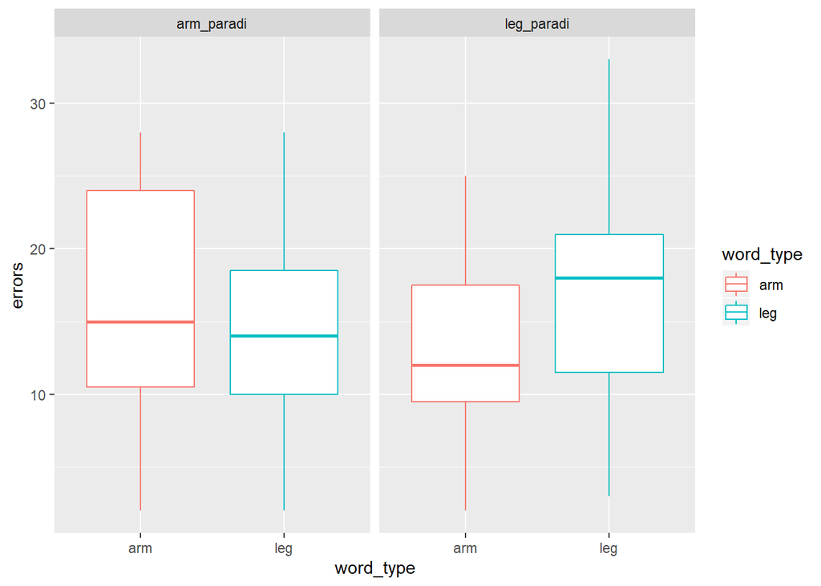

We can qualitatively see the cross-over interaction. Note that although the variability is large, a hypothetical effect may still be detected if there is sufficient consistency within subjects, as it is a within-subjects design. This can be better appreciated in the following plot:

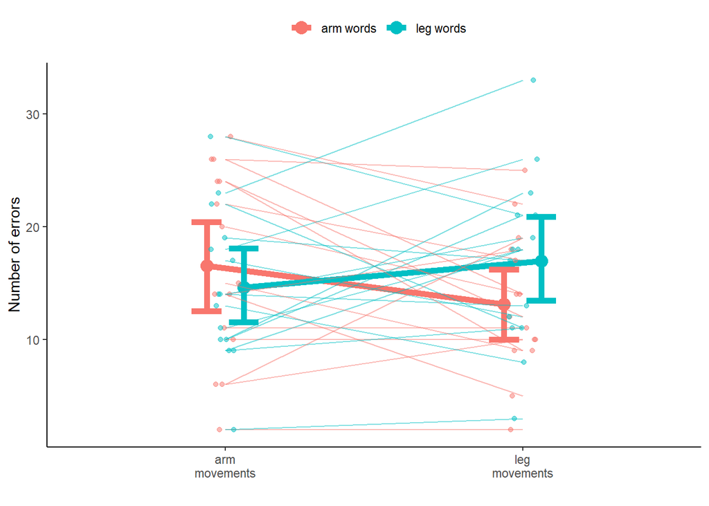

The thick dots and lines show mean number of errors and bootstrapped (non-parametric) 95% CIs. The thinner dots and lines show subject data. There seems to be quite a lot of consistency by subjects, i.e. the slopes of the thin lines mostly go in the same direction as the slope of the thicker lines.

Or we can directly look at the interaction effect by comparing errors in matching conditions (when effector and semantic content are the same, i.e. arm-arm, leg-leg) and mismatching conditions (ffector and semantic content are different, e.g. arm-leg, leg-arm):

```r
d$eff_word <- ifelse(substr(d$movement,1,3) == d$word_type, "match", "mismatch")
kable(head(d, 4))
```

| subject | movement | word_type | errors | eff_word |
| --- | --- | --- | --- | --- |
| 1 | arm_paradi | arm | 14 | match |
| 1 | arm_paradi | leg | 10 | mismatch |
| 1 | leg_paradi | arm | 18 | mismatch |
| 1 | leg_paradi | leg | 21 | match |

```r
d_interact <- d %>%
  group_by(subject, eff_word) %>%
  summarise(errors = mean(errors))
kable(head(d_interact, 2))
```

| subject | eff_word | errors |
| --- | --- | --- |
| 1 | match | 17.5 |
| 1 | mismatch | 14.0 |

We can now plot this by-subject interaction effect:

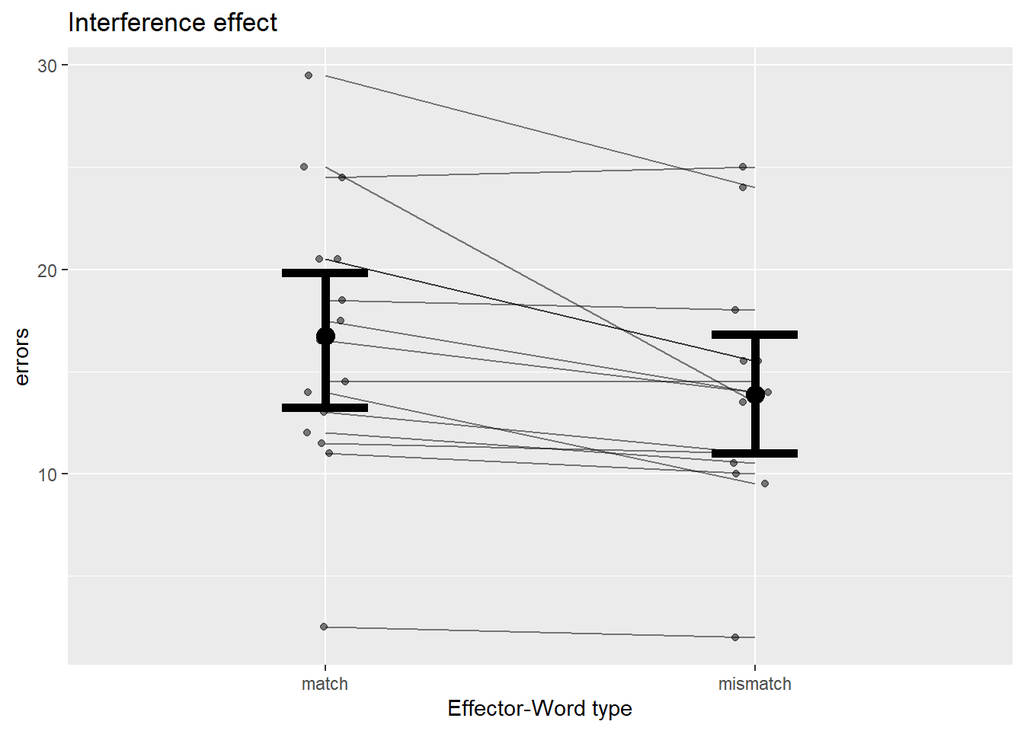

Lines show individual participants. Downward slopes indicate that a participant numerically showed the interference effect.

# 4 Replicate originally reported analysis with ANOVAs (statistically inappropriate analysis)

## 4.1 Data summaries

First, let’s see if our data summaries look like those reported in Table 2 of SP13 (p.226):

```r
d_allconds %>%
  group_by(movement, word_type) %>%
  summarise(
    M  = mean(errors),
    SD = sd(errors)
    ) %>%
  kable(digits = 2)
```

| movement | word_type | M | SD |
| --- | --- | --- | --- |
| arm_paradi | arm | 16.53 | 8.39 |
| arm_paradi | leg | 14.60 | 6.66 |
| artic_suppression | arm | 22.00 | 7.69 |
| artic_suppression | leg | 19.60 | 5.91 |
| control | arm | 7.20 | 4.97 |
| control | leg | 8.33 | 4.19 |
| leg_paradi | arm | 13.13 | 6.23 |
| leg_paradi | leg | 16.93 | 7.56 |

Yes, this replicates the values in Table 2 of SP13!

## 4.2 Anova on full 4 (conditions) x 2 (word categories) design:

Can we replicate the results reported in SP13 (p.225)?

```r
# Following this post:
# https://www.r-bloggers.com/two-way-anova-with-repeated-measures/
aov_orig_allconds <- aov(
  errors ~ movement * word_type + Error(subject / (movement * word_type)),
  data = d_allconds
  )
summary(aov_orig_allconds)
```

```
##
## Error: subject
##           Df Sum Sq Mean Sq F value Pr(>F)
## Residuals 14   2801   200.1
##
## Error: subject:movement
##           Df Sum Sq Mean Sq F value   Pr(>F)
## movement   3   2583   861.1   23.77 3.77e-09 ***
## Residuals 42   1522    36.2
## ---
## Signif. codes:  0 '***' 0.001 '**' 0.01 '*' 0.05 '.' 0.1 ' ' 1
##
## Error: subject:word_type
##           Df Sum Sq Mean Sq F value Pr(>F)
## word_type  1   0.68   0.675   0.049  0.828
## Residuals 14 192.70  13.764
##
## Error: subject:movement:word_type
##                    Df Sum Sq Mean Sq F value   Pr(>F)
## movement:word_type  3  188.5   62.83   7.635 0.000349 ***
## Residuals          42  345.6    8.23
## ---
## Signif. codes:  0 '***' 0.001 '**' 0.01 '*' 0.05 '.' 0.1 ' ' 1
```

Yes, pretty much: The *F*- and *p*-values are identical. What differs are the MSE and I am not sure how they were computed in SP13.

## 4.3 Anova on critical 2 x 2 design

Most importantly, can we replicate the critical results “directly addressing the main hypothesis motivating this study” (SP13, p.226)?

```r
aov_orig <- aov(
  errors ~ movement * word_type + Error(subject / (movement * word_type)),
  data = d
  )
summary(aov_orig)
```

```
##
## Error: subject
##           Df Sum Sq Mean Sq F value Pr(>F)
## Residuals 14   2039   145.7
##
## Error: subject:movement
##           Df Sum Sq Mean Sq F value Pr(>F)
## movement   1    4.3    4.27   0.096  0.761
## Residuals 14  620.2   44.30
##
## Error: subject:word_type
##           Df Sum Sq Mean Sq F value Pr(>F)
## word_type  1  13.07   13.07   1.169  0.298
## Residuals 14 156.43   11.17
##
## Error: subject:movement:word_type
##                    Df Sum Sq Mean Sq F value  Pr(>F)
## movement:word_type  1  123.3  123.27   12.67 0.00314 **
## Residuals          14  136.2    9.73
## ---
## Signif. codes:  0 '***' 0.001 '**' 0.01 '*' 0.05 '.' 0.1 ' ' 1
```

Yes: The *F*-values, degrees of freedom and *p*-values are identical. (As before, however, their reported MSE differs from what we obtain.)

## 4.4 Effect size: Where does the originally reported Cohen’s $d$ come from?

The authors report Cohen’s $d = 1.25$ as the effect size for the critical interaction (p.226). However, since Cohen’s *d* is not an effect size measure that is commonly reported in the context of ANOVAs, it is not clear how they arrived at this figure. Below we try to reproduce it.

### 4.4.1 Does the *d* value come from a t-test?

What if we compare the average difference scores corresponding to the interaction effect, i.e. we run a t-test on the interaction effect we plotted above (match vs mismatch):

```r
d_4ttest <- spread(d_interact, eff_word, errors)
head(d_4ttest, 3)
```

```
## # A tibble: 3 x 3
## # Groups:   subject [15]
##   subject match mismatch
##   <fct>   <dbl>    <dbl>
## 1 1        17.5     14
## 2 2         2.5      2
## 3 3        25       13.5
```

```r
with(d_4ttest, t.test(match, mismatch, paired = TRUE))
```

```
##
##  Paired t-test
##
## data:  match and mismatch
## t = 3.5591, df = 14, p-value = 0.003143
## alternative hypothesis: true difference in means is not equal to 0
## 95 percent confidence interval:
##  1.139174 4.594159
## sample estimates:
## mean of the differences
##                2.866667
```

The t-test comes out significant (but bear in mind that it is not the appropriate analysis, see below). We can compute Cohen’s $d$ for this test.

Cohen’s $d$:

```r
# Following https://rcompanion.org/handbook/I_04.html
with(d_4ttest, (mean(match) - mean(mismatch)) / sd(match - mismatch))
```

```
## [1] 0.9189662
```

```r
# Note we get the same value using the lsr package:
# with(d_4ttest, lsr::cohensD(mismatch, match, method = "paired"))
```

No; we obtain a Cohen’s $d = 0.92$, unlike the figure reported in SP13.

### 4.4.2 Computing $d$ from (partial) $\eta^2$?

Eta squared ($\eta^2$) is the most commonly used measure of effect size for ANOVAs: It “measures the proportion of the total variance in a dependent variable that is associated with […] an independent variable” (Richardson, 2011, p. 135; for an example calculation, see [here](https://psychohawks.wordpress.com/2010/10/31/effect-size-for-analysis-of-variables-anova/)).

```r
eta_sq <- DescTools::EtaSq(aov_orig, type = 1)
eta_sq
```

```
##                         eta.sq eta.sq.part  eta.sq.gen
## movement           0.001379637 0.006832132 0.001443262
## word_type          0.004225140 0.077089479 0.004406871
## movement:word_type 0.039858587 0.475016057 0.040083245
```

```r
# sjstats::eta_sq(aov_orig)  # yields same results
```

The value for the critical movement–word type interaction of interest is one of two:

1. $\eta^2 = 0.04$
2. partial $\eta^2 = 0.48$.

We tried two methods of converting (partial) $\eta^2$ to Cohen’s $d$ and we computed two values with each method, once for $\eta^2$ and once for partial $\eta^2$:

1. [This online calculator](https://www.psychometrica.de/effect_size.html) converts between different effect size measures (see section 13):
   1. When plugging in $\eta^2 = 0.04$, the corresponding effect size is $d = 0.41$, which is far off from the figure reported in SP13.
   2. When plugging in partial $\eta^2 = 0.48$, the corresponding effect size is $d = 1.92$, which is also different from that reported in the original (but in this case, it is greater).
2. [This IBM support website](https://www-01.ibm.com/support/docview.wss?uid=swg21476421) cites formulae to convert between $\eta^2$, Cohen’s $f$, and Cohen’s $d$:
   $$f = \sqrt{ \frac{\eta^2}{1 - \eta^2} };
   d = 2*f$$
   This formula yields exactly the same results as above:
   1. $d=0.41$ if computed from the $\eta^2$,
   2. $d=1.92$ if computed from the partial $\eta^2$.

## 4.5 Conclusion

While we are able to replicate the descriptive statistics and the ANOVA results reported in SP13 from the data the authors have shared, we are unable to reproduce their reported effect size value of Cohen’s $d = 1.25$ (SP13, p. 226). The two methods we have tried yield either $d=0.92$, $d=0.41$, or $d=1.92$.

# 5 Treat data as coming from a binomial distribution, but what is $n$?

SP13 analyzed their data using ANOVAs and t-tests. We instead want to model the dependent variable (DV = number of errors per experimental cell) as coming from a binomial distribution:

$$errors \sim B(n, p)$$

Here, $n$ is the upper bound on the possible number of errors and $p$ is the probability of making an error for each word. We will assume that the maximum number of errors for each trial (i.e., sequence of 4 words) is 4. We also assume that the probability of making an error was the same for all words (we have to do this in our re-analysis as the shared data are aggregated across items). Crucially, we also need to determine how many trials there were per cell and this turns out to be tricky, because SP13 report this inconsistently (see below).

We emailed the original authors about this. Here is the relevant extract, with the authors’ responses as inline comments (email correspondence with Z. Shebani from 1 Apr 2018):

> **Number of trials**

> It says that 24 trials were presented in each block, twelve arm-word and 12 leg-word trials (sect. 2.3, p.225 left column [=LC]). It also says that 4 words were presented per trial (sect. 2.3, p.224 right column [=RC]). This implies that 48 words of each category were shown per block. Since the lists consist of 36 words per category, the above would suggest that some words were repeated in each block (e.g., 12 words per category repeated once), but this is not explicitly stated. Was this the case?

> > Yes, 48 words from each category were shown in each block. Twelve words per category, randomly selected, were repeated once in each block.

> It then says that conditions were run as separate blocks (sect. 2.3, p.225 LC) and that the full set of 72 words were presented twice in each condition (sect. 2.3, p.225 RC). These figures don’t seem to add up: For 72 * 2 = 144 words to be presented, this would require 144 / 4 = 36 trials (assuming 4 words are presented in each trial). In other words, one would need 1.5 blocks per condition, whereas in the study it says that “the conditions were run as separate blocks with twenty-four trials in each block” (p.225). Is there perhaps a typo in the reported numbers, or do we err in our reasoning? In sum, what was the exact number of words per trial, trials per block (we assume equal number of leg- and arm-word trials), and blocks per condition?

> > Line 2 of page 225, RC does indeed contain a typo. As mentioned above, 48 words from each category were presented in each block (36 +12 = 48), therefore, not all words were repeated twice in each block/condition.

> > In sum:

> > Words per trial: 4

> > Trials per block: 24 (12 arm word and 12 leg word trials)

> > Blocks in the experiment: 4

> > Blocks per condition: 1

**Conclusion**

Based on this correspondence, we take there to be 12 trials per experimental cell. Since we assume the maximum number of errors per trial is 4, $n = 12 \times 4 = 48$.

The basic probabilistic model is
$$errors \sim B(48, p)$$
and we are trying to estimate *p*.

```r
d$n <- 48
```

# 6 Bayesian binomial mixed model with *brms* (appropriate re-analysis)

We fit a binomial model using the same priors as we are going to use in our replication:

- Weakly informative priors for all population-level fixed effects coefficients: $N(0,\sigma^2 = 4)$;
- `brms`’s default priors for the variance components (random effects).

## 6.1 Preparations

First, set coding scheme to contrast coding:

```r
# We use numeric coding for consistency with the simulations in Appendix C.
# (Numeric coding allows to remove correlation terms in random effects.)
d$mv <- scale(as.numeric(factor(d$movement)), scale = FALSE) * -2
d$wt <- scale(as.numeric(factor(d$word_type)), scale = FALSE) * -2
d$mv_wt <- d$mv * d$wt
# Note that this coding exactly replicates contrast coding obtained with
# contr.sum(2) on a factor (arm levels = 1, leg levels = -1):
kable(head(d, 4))
```

| subject | movement | word_type | errors | eff_word | n | mv | wt | mv_wt |
| --- | --- | --- | --- | --- | --- | --- | --- | --- |
| 1 | arm_paradi | arm | 14 | match | 48 | 1 | 1 | 1 |
| 1 | arm_paradi | leg | 10 | mismatch | 48 | 1 | -1 | -1 |
| 1 | leg_paradi | arm | 18 | mismatch | 48 | -1 | 1 | -1 |
| 1 | leg_paradi | leg | 21 | match | 48 | -1 | -1 | 1 |

See which priors can be specified for this model and what defaults there are?

```r
get_prior(
  errors | trials(n) ~ 1 + mv * wt + (1 + mv * wt | subject),
  data = d,
  family = "binomial"
  )
```

```
##                  prior     class      coef   group resp dpar nlpar bound
## 1                              b
## 2                              b        mv
## 3                              b     mv:wt
## 4                              b        wt
## 5               lkj(1)       cor
## 6                            cor           subject
## 7  student_t(3, 0, 10) Intercept
## 8  student_t(3, 0, 10)        sd
## 9                             sd           subject
## 10                            sd Intercept subject
## 11                            sd        mv subject
## 12                            sd     mv:wt subject
## 13                            sd        wt subject
```

Specify weakly informative priors $N(0,\sigma^2 = 4)$ for population-level fixed effects:

```r
myprior <- set_prior("normal(0, 2)", class = "b")
# NB: In Stan a normal distribution is specified with sigma (*not* sigma^2), see
# https://mc-stan.org/docs/2_18/functions-reference/normal-distribution.html
# and
# https://stackoverflow.com/questions/52893379/stan-in-r-standard-deviation-or-variance-in-normal-distribution
```

## 6.2 Fit the models

The following function fit pairs of models. One is the *full* model: it contains the population-level interaction effect of interest (movement-by-word type). The other is the *null* model: it is in all respects identical to the full, except that it does not contain the population-level critical interaction.

(NB: The function takes the formula of the full model as input.)

```r
# Function to fit brms full and null models given a formula and save them to
# disk with appropriate name defined by RE (string argument):
fit_brm <- function(formu_str, RE, df = d) {
  f <- as.formula(formu_str)
  full <- brm(formula = f, data = df, prior = myprior, family = "binomial",
              iter = 15000, warmup = 2000, chains = 4, save_all_pars = TRUE)
  null <- update(full, ~ . -mv_wt, save_all_pars = TRUE)
  BF <- brms::bayes_factor(full, null)
  l <- list(full, null, BF)
  saveRDS(l, paste("data/sp13_bfm_", RE, ".rds", sep = ""))
  l
}
```

Fit and save (the following snippet needs to be uncommented and run the first time):

```r
# # Fit maximal RE models (in the spirit of Barr et al., 2013)
# bfm_max <- fit_brm(
#   formu_str = "errors | trials(n) ~ 1 + mv + wt + mv_wt + (1 + mv + wt + mv_wt | subject)",
#   RE = "max"
#   )
```

Load from disk (once it has been run):

```r
bfm_max <- readRDS("data/sp13_bfm_max.rds")
# It's a list with three objects: the full model, the null model, and the BF
# for the interaction based on bridge sampling. Store the full model separately:
bfm_full <- bfm_max[[1]]
```

## 6.3 Summary and interpretation of the full model

```r
summary(bfm_full)
```

```
##  Family: binomial
##   Links: mu = logit
## Formula: errors | trials(n) ~ 1 + mv + wt + mv_wt + (1 + mv + wt + mv_wt | subject)
##    Data: df (Number of observations: 60)
## Samples: 4 chains, each with iter = 15000; warmup = 2000; thin = 1;
##          total post-warmup samples = 52000
##
## Group-Level Effects:
## ~subject (Number of levels: 15)
##                      Estimate Est.Error l-95% CI u-95% CI Rhat Bulk_ESS
## sd(Intercept)            0.81      0.20     0.52     1.28 1.00    17119
## sd(mv)                   0.35      0.10     0.20     0.58 1.00    21811
## sd(wt)                   0.09      0.06     0.00     0.24 1.00    20276
## sd(mv_wt)                0.07      0.05     0.00     0.19 1.00    26828
## cor(Intercept,mv)        0.13      0.28    -0.44     0.64 1.00    36169
## cor(Intercept,wt)        0.12      0.41    -0.71     0.82 1.00    69247
## cor(mv,wt)               0.23      0.40    -0.64     0.87 1.00    51229
## cor(Intercept,mv_wt)     0.11      0.43    -0.74     0.85 1.00    72197
## cor(mv,mv_wt)            0.01      0.42    -0.78     0.79 1.00    65808
## cor(wt,mv_wt)           -0.06      0.45    -0.84     0.78 1.00    39934
##                      Tail_ESS
## sd(Intercept)           27439
## sd(mv)                  33225
## sd(wt)                  23872
## sd(mv_wt)               27930
## cor(Intercept,mv)       37698
## cor(Intercept,wt)       36966
## cor(mv,wt)              36582
## cor(Intercept,mv_wt)    35176
## cor(mv,mv_wt)           39237
## cor(wt,mv_wt)           41143
##
## Population-Level Effects:
##           Estimate Est.Error l-95% CI u-95% CI Rhat Bulk_ESS Tail_ESS
## Intercept    -0.86      0.22    -1.31    -0.43 1.00    11207    19539
## mv            0.02      0.10    -0.19     0.22 1.00    25245    31146
## wt           -0.05      0.05    -0.16     0.05 1.00    56119    37882
## mv_wt         0.15      0.05     0.05     0.24 1.00    66705    38710
##
## Samples were drawn using sampling(NUTS). For each parameter, Eff.Sample
## is a crude measure of effective sample size, and Rhat is the potential
## scale reduction factor on split chains (at convergence, Rhat = 1).
```

**Interpretation (backtransforming to odds)**:

- The estimated average odds of an error (intercept) is $e ^ {-0.86} = 0.42$ (corresponding to an average probability of 0.3 of making an error for any word).
- Neither the type of movement (`mv`) nor the type of word (`wt`) have a significant effect on the odds of making an error.
- The critical interaction (`mv_wt`), however, is significant (see next point) and tells us that the odds of making an error if the effector of the movement *coincides* with the word type (as opposed to when the two differ) is $e ^ {0.15} =1.16$. In other words, participants were 1.16 times more likely to make an error if effector and semantics match than if they mismatch. This is the *interference effect* of interest!
- The *brms* model features 95% credible intervals for parameter estimates. The 95% credible interval for the critical interaction is $[0.05, 0.24]$ (in log-odds). Note that zero is not contained in this interval: that is why the effect can be considered significant.

## 6.4 Is the effect supported by the data? (Bayes factor)

A more stringent way to evaluate the significance of the interaction effect is to use Bayes factors (BF). In this case we evaluate two models, the full and the null models fitted (and loaded) above.

There are different ways to compute Bayes factors. We used bridge sampling, which is the one recommended in [this](https://rpubs.com/lindeloev/bayes_factors) post by Jonas Kristoffer Lindeløv (and also by [Paul Buerkner](https://twitter.com/paulbuerkner/status/963585470482604033?lang=en), the developer of `brms`, himself). It is also the method to compute BFs that we will use for our own study

```r
# It's the 3rd element in the list bfm_max
# Once run, load from disk:
BF_bfm <- bfm_max[[3]]
BF_bfm
```

```
## Estimated Bayes factor in favor of bridge1 over bridge2: 1.69284
```

This BF constitutes only inconclusive or anecdotical evidence in favour of the alternative hypothesis ($H_1$) against the null ($H_0$): $1< BF_{10} < 6$.

## 6.5 Posterior densities

`brms` also lets us plot the posterior distribution of the model estimates. The posterior distribution for the interfefence effect is shown in the 4th panel of the left column.

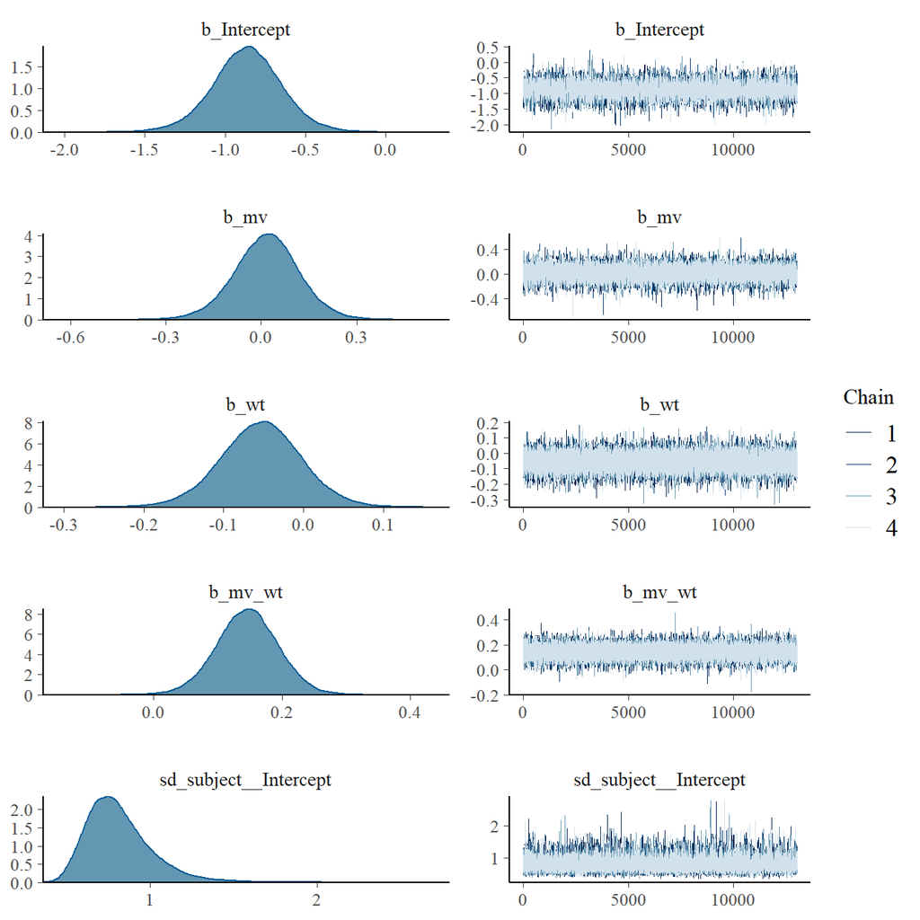

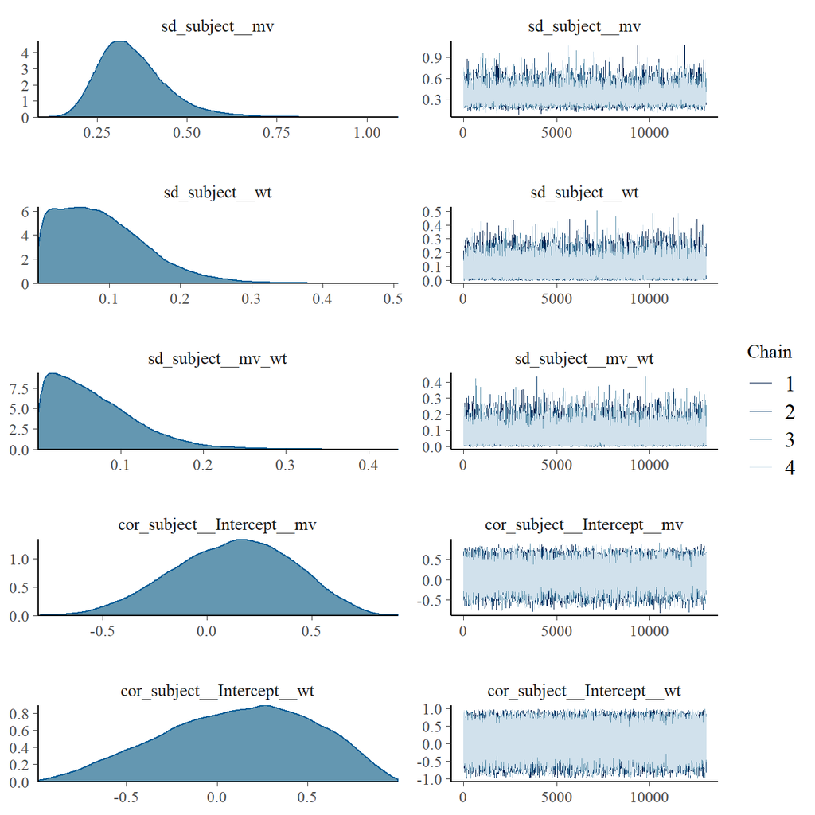

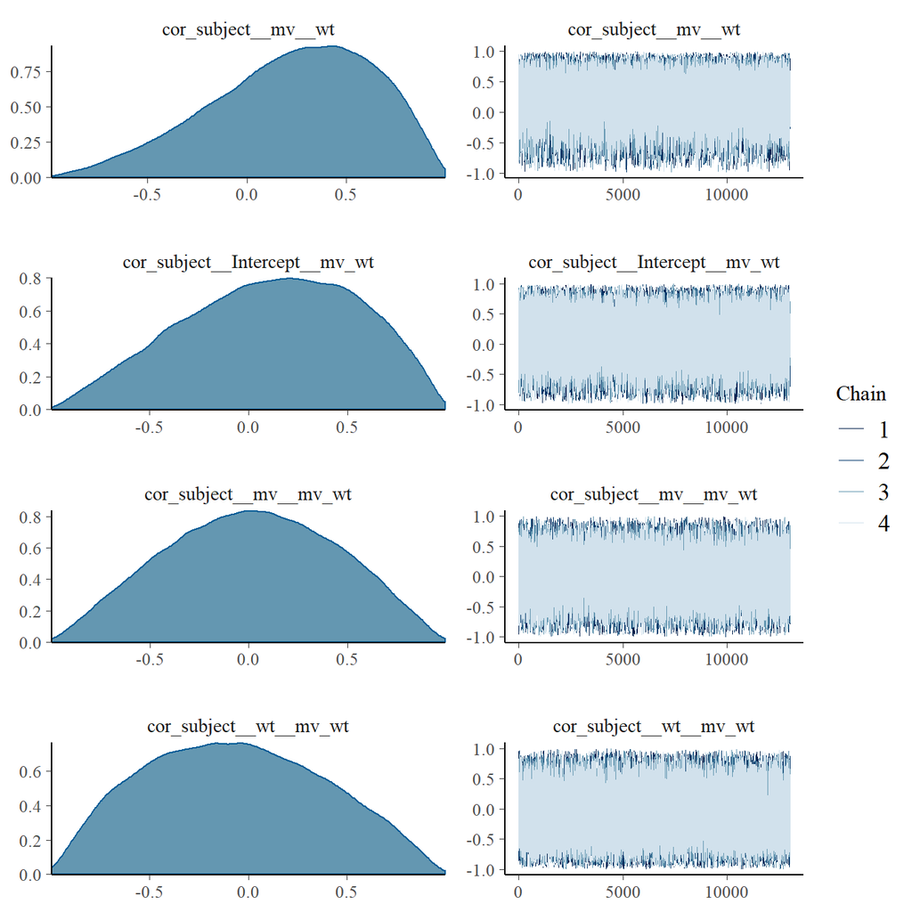

```r
plot(bfm_full)
```

# 7 Sanity check: GLMM with *lme4*

As a sanity check, we also fit a frequentist version of the GLMM above with the *lme4* package. Do we roughly obtain the same estimates?

We fit an equivalent model to the one above:

```r
fm_binom <- glmer(
  cbind(errors, n - errors) ~ 1 + mv + wt + mv_wt + (1 + mv + wt + mv_wt | subject),
  data = d,
  family = "binomial"
  )
```

```
## boundary (singular) fit: see ?isSingular
```

The `boundary (singular) fit` warning is probably due an overspecified model, as we only have four observations per participant but we try to estimate random effect slopes for the 2x2 design. The estimates can nevertheless be trusted (P. Alday, personal communication, 17 Dec 2019). As shown below, the model estimates in the `lme4` are also very similar to those from `brms`, which constitutes at least one type of validation since two different methods yield very similar results.

```r
summary(fm_binom)
```

```
## Generalized linear mixed model fit by maximum likelihood (Laplace
##   Approximation) [glmerMod]
##  Family: binomial  ( logit )
## Formula: cbind(errors, n - errors) ~ 1 + mv + wt + mv_wt + (1 + mv + wt +
##     mv_wt | subject)
##    Data: d
##
##      AIC      BIC   logLik deviance df.resid
##    388.3    417.6   -180.2    360.3       46
##
## Scaled residuals:
##      Min       1Q   Median       3Q      Max
## -1.84585 -0.46014  0.06906  0.46059  1.42637
##
## Random effects:
##  Groups  Name        Variance Std.Dev. Corr
##  subject (Intercept) 0.440765 0.66390
##          mv          0.081533 0.28554   0.21
##          wt          0.006919 0.08318   0.43  0.76
##          mv_wt       0.003449 0.05873   0.67  0.08 -0.20
## Number of obs: 60, groups:  subject, 15
##
## Fixed effects:
##             Estimate Std. Error z value Pr(>|z|)
## (Intercept) -0.85707    0.17716  -4.838 1.31e-06 ***
## mv           0.01558    0.08607   0.181  0.85635
## wt          -0.05736    0.04882  -1.175  0.24004
## mv_wt        0.13558    0.04635   2.926  0.00344 **
## ---
## Signif. codes:  0 '***' 0.001 '**' 0.01 '*' 0.05 '.' 0.1 ' ' 1
##
## Correlation of Fixed Effects:
##       (Intr) mv     wt
## mv     0.177
## wt     0.192  0.270
## mv_wt  0.203  0.042 -0.024
## convergence code: 0
## boundary (singular) fit: see ?isSingular
```

The point estimates of the `lme4` and `brms` models are almost identical:

```r
tibble(
  Coefficient = rownames(fixef(bfm_full)),
  brms = fixef(bfm_full)[, 1],
  lme4 = fixef(fm_binom)
) %>%
  kable(digits = 3)
```

| Coefficient | brms | lme4 |
| --- | --- | --- |
| Intercept | -0.865 | -0.857 |
| mv | 0.017 | 0.016 |
| wt | -0.053 | -0.057 |
| mv_wt | 0.146 | 0.136 |

Note that the estimated SEMs for the fixed-effects coefficients also are quite comparable. This shows that our results are not specific to using Bayesian GLMMs (in `brms`).

# 8 Conclusion

The interference effect is suggested by the evaluation of the critical coefficient (movement-by-word type interaction) in the full model. The effect size of this interference effect is rather small: 0.15 log-odds. This can be compared to the guidelines proposed by Chen, Cohen, and Chen (2010), where an effect of 0.5 log-odds would be considered a “small” effect. The current effect being less than one third of this could even be considered very small.

Importantly, the BF analysis does only yield “anecdotical” or “inconclusive” evidence for the existence of the effect.